# Global Shark Attack Incident Report and Analysis

```python
import pandas as pd
```

```python
df=pd.read_csv(r"global_shark_attacks.csv")
```

## How has the annual frequency of shark attacks (provoked vs. unprovoked) evolved globally over the past 50 years?

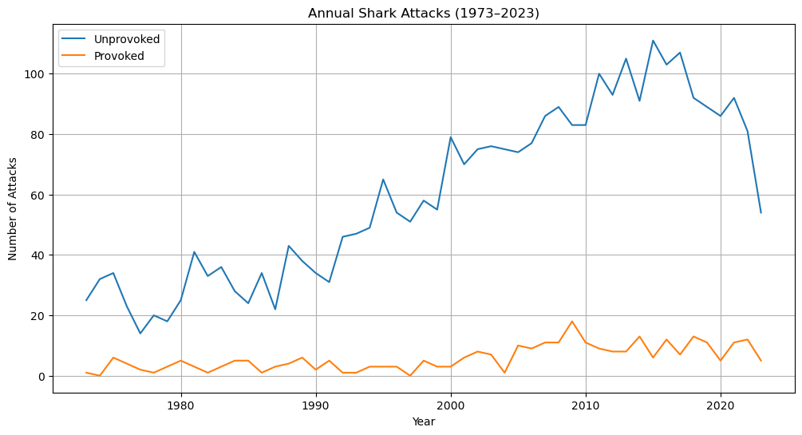

```python
import pandas as pd
import matplotlib.pyplot as plt

# Load data
df = pd.read_csv(r'global_shark_attacks.csv', encoding='latin1')
df['year'] = pd.to_numeric(df['year'], errors='coerce')  # Clean year column
df = df.dropna(subset=['year', 'type'])  # Drop rows with missing year/type

# Filter last 50 years and valid types
df = df[(df['year'] >= 1973) & (df['year'] <= 2023)]
df_type = df[df['type'].isin(['Unprovoked', 'Provoked'])]

# Group data
annual_trend = df_type.groupby(['year', 'type']).size().unstack().fillna(0)

# Plot
plt.figure(figsize=(12, 6))
plt.plot(annual_trend.index, annual_trend['Unprovoked'], label='Unprovoked')
plt.plot(annual_trend.index, annual_trend['Provoked'], label='Provoked')
plt.xlabel('Year')
plt.ylabel('Number of Attacks')
plt.title('Annual Shark Attacks (1973–2023)')
plt.legend()
plt.grid(True)
plt.savefig("Annual Shark Attacks.png")
plt.show()
```

## Are there seasonal or diurnal patterns in shark attack occurrences, and do these vary by geographic region?

[figure not shown]

```python
# Seasonal patterns (monthly)
df['date'] = pd.to_datetime(df['date'], errors='coerce')
df['month'] = df['date'].dt.month
monthly = df['month'].value_counts().sort_index()

# Diurnal patterns (time of day)
def categorize_time(t):
    if pd.isna(t): return 'Unknown'
    if 'h' in str(t):
        hour = int(str(t).split('h')[0])
        if 5 <= hour < 12: return 'Morning'
        elif 12 <= hour < 17: return 'Afternoon'
        elif 17 <= hour < 21: return 'Evening'
        else: return 'Night'
    else: return 'Unknown'

# Plot
fig, axes = plt.subplots(1, 2, figsize=(15, 5))
axes[0].bar(monthly.index, monthly.values)
axes[0].set_title('Monthly Distribution of Attacks')
plt.show()
```

## What proportion of reported attacks are later invalidated, and what are the most common reasons for invalidation?

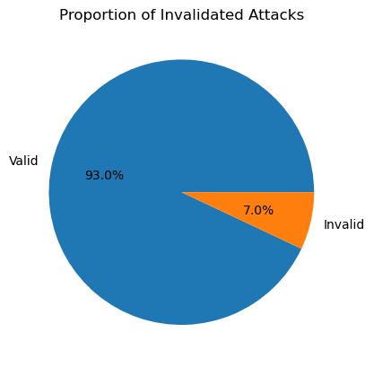

```python
invalid = df[df['type'] == 'Invalid']
valid = df[df['type'] != 'Invalid']

# Pie chart
labels = ['Valid', 'Invalid']
sizes = [len(valid), len(invalid)]
plt.pie(sizes, labels=labels, autopct='%1.1f%%')
plt.title('Proportion of Invalidated Attacks')
plt.savefig("Proportion of Invalidated Attacks.png")
plt.show()
```

## Which countries and coastal regions have the highest incidence of shark attacks, and how does this correlate with local marine ecosystems?

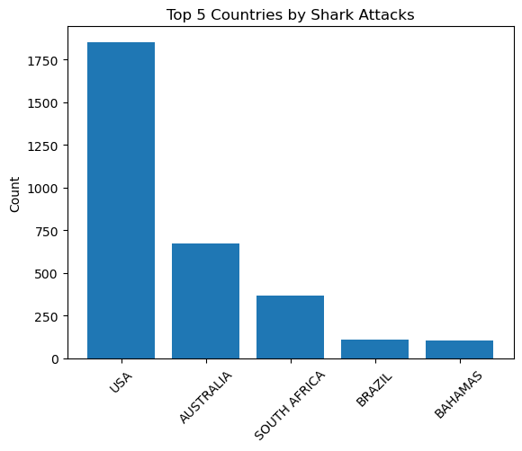

```python
top_countries = df['country'].value_counts().head(5)
plt.bar(top_countries.index, top_countries.values)
plt.title('Top 5 Countries by Shark Attacks')
plt.ylabel('Count')
plt.xticks(rotation=45)
plt.savefig("Top 5 Countries by Shark Attacks.png")
plt.show()
```

## Do fatal attacks cluster in specific geographic areas, and what factors (e.g., shark species, human activity) drive this clustering?

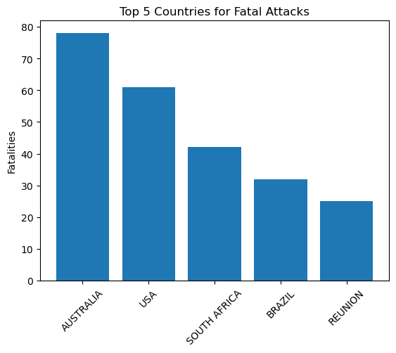

```python
fatal = df[df['fatal_y_n'] == 'Y']
top_fatal = fatal['country'].value_counts().head(5)
plt.bar(top_fatal.index, top_fatal.values)
plt.title('Top 5 Countries for Fatal Attacks')
plt.ylabel('Fatalities')
plt.xticks(rotation=45)
plt.savefig("Top 5 Countries for Fatal Attacks.png")
plt.show()
```

## How do shark attack rates in popular tourist destinations compare to less-frequented coastal areas?

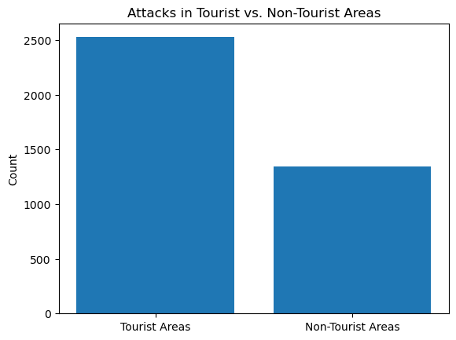

```python
tourist = df[df['country'].isin(['USA', 'AUSTRALIA'])]
non_tourist = df[~df['country'].isin(['USA', 'AUSTRALIA'])]

# Compare counts
plt.bar(['Tourist Areas', 'Non-Tourist Areas'], [len(tourist), len(non_tourist)])
plt.title('Attacks in Tourist vs. Non-Tourist Areas')
plt.ylabel('Count')
plt.savefig("Attacks in Tourist vs. Non-Tourist Areas.png")
plt.show()
```

## What age and gender demographics are most frequently involved in shark attacks, and does this vary by activity (e.g., surfing, spearfishing)?

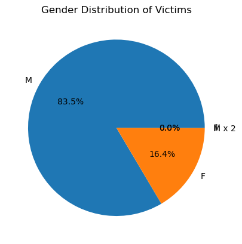

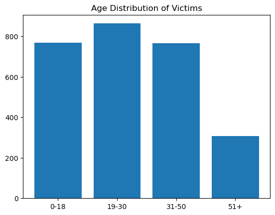

```python
# Gender distribution
gender = df['sex'].value_counts()
plt.pie(gender.values, labels=gender.index, autopct='%1.1f%%')
plt.title('Gender Distribution of Victims')
plt.savefig("Gender Distribution of Victims.png")
plt.show()

# Age distribution
df['age'] = pd.to_numeric(df['age'], errors='coerce')
age_bins = [0, 18, 30, 50, 100]
age_labels = ['0-18', '19-30', '31-50', '51+']
df['age_group'] = pd.cut(df['age'], bins=age_bins, labels=age_labels)
age_dist = df['age_group'].value_counts().sort_index()
plt.bar(age_dist.index, age_dist.values)
plt.title('Age Distribution of Victims')
plt.savefig("Age Distribution of Victims.png")
plt.show()
```

## Which recreational activities (e.g., surfing, swimming, spearfishing) are associated with the highest risk of unprovoked attacks?

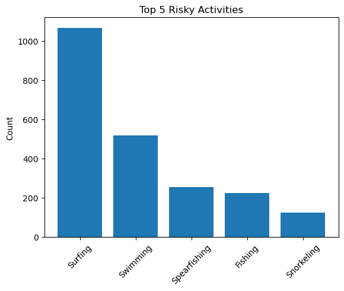

```python
activities = df['activity'].value_counts().head(5)
plt.bar(activities.index, activities.values)
plt.title('Top 5 Risky Activities')
plt.ylabel('Count')
plt.xticks(rotation=45)
plt.savefig("Top 5 Risky Activities.png")
plt.show()
```

## How do fatality rates differ between provoked and unprovoked incidents, and what factors (e.g., shark species, victim age) influence outcomes?

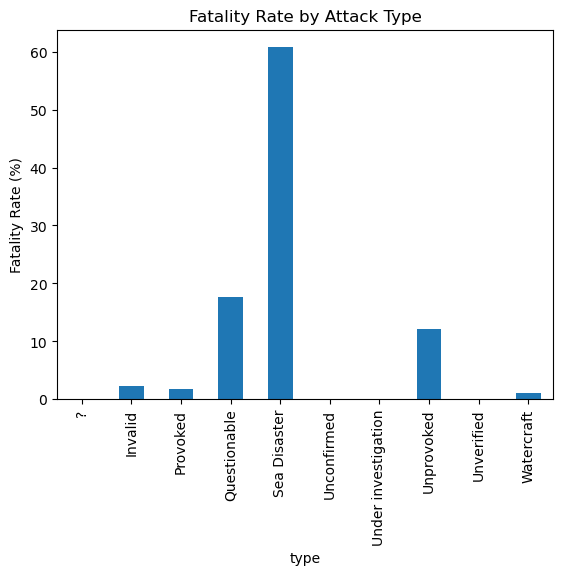

```python
fatal_rates = df.groupby('type')['fatal_y_n'].apply(lambda x: (x == 'Y').mean() * 100)
fatal_rates = fatal_rates.dropna()
fatal_rates.plot(kind='bar')
plt.title('Fatality Rate by Attack Type')
plt.ylabel('Fatality Rate (%)')
plt.savefig("Fatality Rate by Attack Type.png")
plt.show()
```

## Which shark species are most frequently implicated in attacks, and how does their involvement correlate with attack severity (fatal vs. non-fatal)?

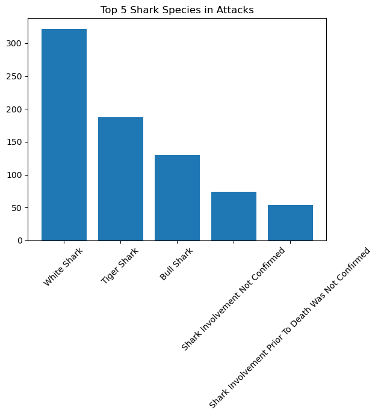

```python
# Simplify species names
df['species'] = df['species'].str.split(',').str[0].str.strip().str.title()
top_species = df['species'].value_counts().head(5)
plt.bar(top_species.index, top_species.values)
plt.title('Top 5 Shark Species in Attacks')
plt.xticks(rotation=45)
plt.savefig("Top 5 Shark Species in Attacks.png")
plt.show()
```

## Are certain species more likely to be involved in attacks during specific times of day or in particular regions?

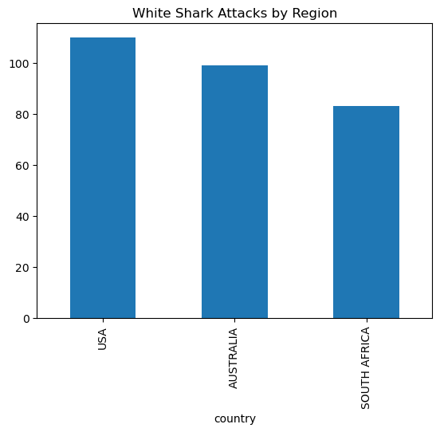

```python
white_shark = df[df['species'] == 'White Shark']
white_shark_regions = white_shark['country'].value_counts().head(3)
white_shark_regions.plot(kind='bar')
plt.title('White Shark Attacks by Region')
plt.savefig("White Shark Attacks by Region.png")
plt.show()
```

## How do attacks involving large predatory species (e.g., white sharks, tiger sharks) differ in outcome compared to smaller species?

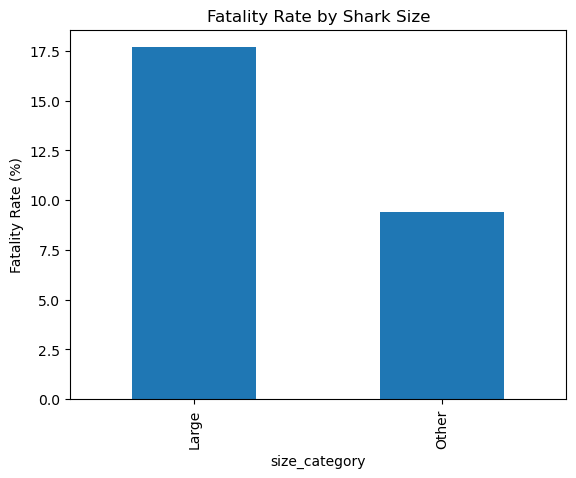

```python
large_species = ['White Shark', 'Tiger Shark', 'Bull Shark']
df['size_category'] = df['species'].apply(lambda x: 'Large' if x in large_species else 'Other')
fatality_by_size = df.groupby('size_category')['fatal_y_n'].apply(lambda x: (x == 'Y').mean() * 100)
fatality_by_size.plot(kind='bar')
plt.title('Fatality Rate by Shark Size')
plt.ylabel('Fatality Rate (%)')
plt.savefig("Fatality Rate by Shark Size.png")
plt.show()
```

## How effective are modern mitigation strategies (e.g., shark nets, drones) in reducing attack rates in high-risk areas?

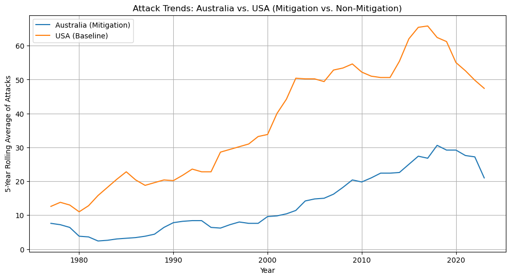

```python
# Filter data for Australia and USA
df_au = df[df['country'] == 'AUSTRALIA']
df_us = df[df['country'] == 'USA']

# Group by year
au_attacks = df_au['year'].value_counts().sort_index().rolling(5).mean()
us_attacks = df_us['year'].value_counts().sort_index().rolling(5).mean()

# Plot
plt.figure(figsize=(12, 6))
plt.plot(au_attacks.index, au_attacks.values, label='Australia (Mitigation)')
plt.plot(us_attacks.index, us_attacks.values, label='USA (Baseline)')
plt.xlabel('Year')
plt.ylabel('5-Year Rolling Average of Attacks')
plt.title('Attack Trends: Australia vs. USA (Mitigation vs. Non-Mitigation)')
plt.legend()
plt.grid(True)
plt.show()
```

## How does media coverage of shark attacks align with statistical trends, and what discrepancies exist in public perception versus data-driven realities?

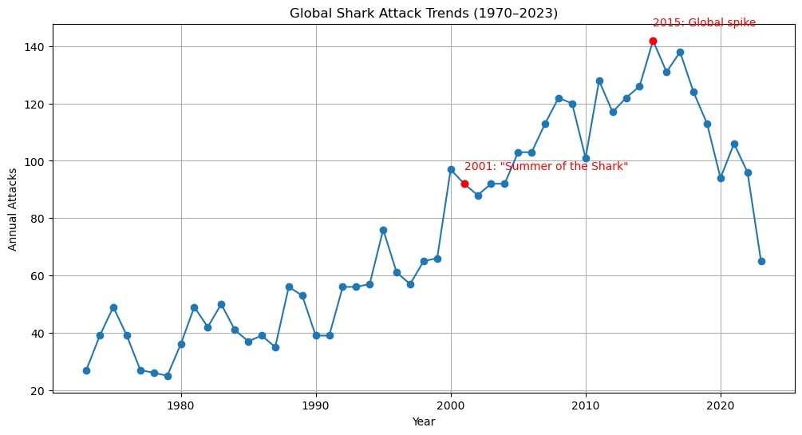

```python
# Annual attack counts
annual_counts = df['year'].value_counts().sort_index()

# Plot
plt.figure(figsize=(12, 6))
plt.plot(annual_counts.index, annual_counts.values, marker='o')
plt.xlabel('Year')
plt.ylabel('Annual Attacks')
plt.title('Global Shark Attack Trends (1970–2023)')

# Highlight years with high media attention (example: 2001, 2015)
media_years = [2001, 2015]
for year in media_years:
    plt.scatter(year, annual_counts.get(year, 0), color='red', zorder=5)
plt.text(2001, annual_counts.get(2001, 0)+5, '2001: "Summer of the Shark"', color='red')
plt.text(2015, annual_counts.get(2015, 0)+5, '2015: Global spike', color='red')
plt.grid(True)
plt.savefig("Global Shark Attack Trends.png")
plt.show()
```